In this study i will try to build a model for predicting income levels of people observed with 15 features like Education, Occupation, Race, Relationship and etc.

# Organon Project

# 1. The Project

The data set named ?ADULT_TRAIN_DATA_TABLE? is gathered from the United States Census Bureau. It contains 17 columns including the demographic information and economic conditions of the people in the sample. Target column having value 1 indicates that the person has an annual income of more than $50K.

I will try to build a classification model which predicts if a person has an annual income of more than $50K.

The model will be built on Rstudio and a report will be created in an Rmarkdown document representing all steps throughout building the model.

The project will contain following parts:

- Data preparation steps
- The method used for developing the predictive model
- Interpretation of the model outputs : selected features and model performance
- How the model is validated

# 2. Data Preperation

## 2.1 Data Import

Before starting, the double quotes removed from the source file using notepad+.

The data import has been peformed with read_csv. “RECORD_ID” field is just a unique id of each observation and the “PROXY” field has the same information with “TARGET” field. So they are skipped at the time of import. Our dependent variable will be TARGET field.

```r
ORdata <- read_csv("C:/Users/Acer-nb/Downloads/ADULT TRAIN DATA TABLE modelleme.csv",
                   col_types = cols(PROXY = col_skip(), RECORD_ID = col_skip()))
```

## 2.2 Understanding data

There are 32561 observations in our data.

```r
dim(ORdata)
```

```
## [1] 32561    15
```

Beside our dependent variable TARGET, we have 14 independent variables to build our model.

```r
summary(ORdata)
```

```
##       AGE         WORKCLASS            FNLWGHT         EDUCATION
##  Min.   :17.00   Length:32561       Min.   :  12285   Length:32561
##  1st Qu.:28.00   Class :character   1st Qu.: 117827   Class :character
##  Median :37.00   Mode  :character   Median : 178356   Mode  :character
##  Mean   :38.58                      Mean   : 189778
##  3rd Qu.:48.00                      3rd Qu.: 237051
##  Max.   :90.00                      Max.   :1484705
##  EDUCATION_NUM   MARITAL_STATUS      OCCUPATION        RELATIONSHIP
##  Min.   : 1.00   Length:32561       Length:32561       Length:32561
##  1st Qu.: 9.00   Class :character   Class :character   Class :character
##  Median :10.00   Mode  :character   Mode  :character   Mode  :character
##  Mean   :10.08
##  3rd Qu.:12.00
##  Max.   :16.00
##      RACE               SEX             CAPITAL_GAIN    CAPITAL_LOSS
##  Length:32561       Length:32561       Min.   :    0   Min.   :   0.0
##  Class :character   Class :character   1st Qu.:    0   1st Qu.:   0.0
##  Mode  :character   Mode  :character   Median :    0   Median :   0.0
##                                        Mean   : 1078   Mean   :  87.3
##                                        3rd Qu.:    0   3rd Qu.:   0.0
##                                        Max.   :99999   Max.   :4356.0
##  HOURS_PER_WEEK    COUNTRY              TARGET
##  Min.   : 1.00   Length:32561       Min.   :0.0000
##  1st Qu.:40.00   Class :character   1st Qu.:0.0000
##  Median :40.00   Mode  :character   Median :0.0000
##  Mean   :40.44                      Mean   :0.2408
##  3rd Qu.:45.00                      3rd Qu.:0.0000
##  Max.   :99.00                      Max.   :1.0000
```

Here ise a summary representation of variable types. Variables in the data have numeric and character types.

```r
sapply(ORdata,class)
```

```
##            AGE      WORKCLASS        FNLWGHT      EDUCATION  EDUCATION_NUM
##      "integer"    "character"      "integer"    "character"      "integer"
## MARITAL_STATUS     OCCUPATION   RELATIONSHIP           RACE            SEX
##    "character"    "character"    "character"    "character"    "character"
##   CAPITAL_GAIN   CAPITAL_LOSS HOURS_PER_WEEK        COUNTRY         TARGET
##      "integer"      "integer"      "integer"    "character"      "integer"
```

## 2.3 Exploring and Shaping Data

Let’s have a closer look at the independent variables.

- WORKCLASS

```r
table(ORdata$WORKCLASS)
```

```
##
##                ?      Federal-gov        Local-gov     Never-worked
##             1836              960             2093                7
##          Private     Self-emp-inc Self-emp-not-inc        State-gov
##            22696             1116             2541             1298
##      Without-pay
##               14
```

There are 1836 unknown WORKCLASS values. This is almost same in OCCUPATION values.

- OCCUPATION

```r
table(ORdata$OCCUPATION)
```

```
##
##                 ?      Adm-clerical      Armed-Forces      Craft-repair
##              1843              3770                 9              4099
##   Exec-managerial   Farming-fishing Handlers-cleaners Machine-op-inspct
##              4066               994              1370              2002
##     Other-service   Priv-house-serv    Prof-specialty   Protective-serv
##              3295               149              4140               649
##             Sales      Tech-support  Transport-moving
##              3650               928              1597
```

- COUNTRY

```r
table(ORdata$COUNTRY)
```

```
##
##                          ?                   Cambodia
##                        583                         19
##                     Canada                      China
##                        121                         75
##                   Columbia                       Cuba
##                         59                         95
##         Dominican-Republic                    Ecuador
##                         70                         28
##                El-Salvador                    England
##                        106                         90
##                     France                    Germany
##                         29                        137
##                     Greece                  Guatemala
##                         29                         64
##                      Haiti         Holand-Netherlands
##                         44                          1
##                   Honduras                       Hong
##                         13                         20
##                    Hungary                      India
##                         13                        100
##                       Iran                    Ireland
##                         43                         24
##                      Italy                    Jamaica
##                         73                         81
##                      Japan                       Laos
##                         62                         18
##                     Mexico                  Nicaragua
##                        643                         34
## Outlying-US(Guam-USVI-etc)                       Peru
##                         14                         31
##                Philippines                     Poland
##                        198                         60
##                   Portugal                Puerto-Rico
##                         37                        114
##                   Scotland                      South
##                         12                         80
##                     Taiwan                   Thailand
##                         51                         18
##            Trinadad&Tobago              United-States
##                         19                      29170
##                    Vietnam                 Yugoslavia
##                         67                         16
```

In country data there 583 unknowns.

- EDUCATION

```r
table(ORdata$EDUCATION)
```

```
##
##         10th         11th         12th      1st-4th      5th-6th
##          933         1175          433          168          333
##      7th-8th          9th   Assoc-acdm    Assoc-voc    Bachelors
##          646          514         1067         1382         5355
##    Doctorate      HS-grad      Masters    Preschool  Prof-school
##          413        10501         1723           51          576
## Some-college
##         7291
```

- MARITAL_STATUS

```r
table(ORdata$MARITAL_STATUS)
```

```
##
##              Divorced     Married-AF-spouse    Married-civ-spouse
##                  4443                    23                 14976
## Married-spouse-absent         Never-married             Separated
##                   418                 10683                  1025
##               Widowed
##                   993
```

- RELATIONSHIP

```r
table(ORdata$RELATIONSHIP)
```

```
##
##        Husband  Not-in-family Other-relative      Own-child      Unmarried
##          13193           8305            981           5068           3446
##           Wife
##           1568
```

- RACE

```r
table(ORdata$RACE)
```

```
##
## Amer-Indian-Eskimo Asian-Pac-Islander              Black
##                311               1039               3124
##              Other              White
##                271              27816
```

- SEX

```r
table(ORdata$SEX)
```

```
##
## Female   Male
##  10771  21790
```

- EDUCATION_NUM

```r
table(ORdata$EDUCATION_NUM)
```

```
##
##     1     2     3     4     5     6     7     8     9    10    11    12
##    51   168   333   646   514   933  1175   433 10501  7291  1382  1067
##    13    14    15    16
##  5355  1723   576   413
```

EDUCATION and EDUCATION_NUM fields have the same information. E.g. The records having EDUCATION value 10th have the EDUCATION_NUM value 6. So for simplifying purpose i will remove EDUCATION(with column index = 4) field.

```r
ORdata <- ORdata[,-4]
```

Let’s save the index of continuous and categorical variables in seperate lists.

```r
sapply(ORdata,is.numeric)
```

```
##            AGE      WORKCLASS        FNLWGHT  EDUCATION_NUM MARITAL_STATUS
##           TRUE          FALSE           TRUE           TRUE          FALSE
##     OCCUPATION   RELATIONSHIP           RACE            SEX   CAPITAL_GAIN
##          FALSE          FALSE          FALSE          FALSE           TRUE
##   CAPITAL_LOSS HOURS_PER_WEEK        COUNTRY         TARGET
##           TRUE           TRUE          FALSE           TRUE
```

```r
num_list <- c(1,3,10,11,12)
cat_list <- c(2,4,5,6,7,8,9,13)
```

Let’s change the type of character variables and EDUCATION_NUM as categorical(factor).

```r
ORdata[sapply(ORdata, is.character)] <- lapply(ORdata[sapply(ORdata, is.character)], as.factor)
ORdata$EDUCATION_NUM <- as.factor(ORdata$EDUCATION_NUM)
ORdata$TARGET <- as.factor(ORdata$TARGET)
str(ORdata)
```

```
## Classes 'tbl_df', 'tbl' and 'data.frame':    32561 obs. of  14 variables:
##  $ AGE           : int  39 50 38 53 28 37 49 23 32 34 ...
##  $ WORKCLASS     : Factor w/ 9 levels "?","Federal-gov",..: 8 7 5 5 5 5 5 5 5 5 ...
##  $ FNLWGHT       : int  77516 83311 215646 234721 338409 284582 160187 122272 205019 245487 ...
##  $ EDUCATION_NUM : Factor w/ 16 levels "1","2","3","4",..: 13 13 9 7 13 14 5 13 12 4 ...
##  $ MARITAL_STATUS: Factor w/ 7 levels "Divorced","Married-AF-spouse",..: 5 3 1 3 3 3 4 5 5 3 ...
##  $ OCCUPATION    : Factor w/ 15 levels "?","Adm-clerical",..: 2 5 7 7 11 5 9 2 13 15 ...
##  $ RELATIONSHIP  : Factor w/ 6 levels "Husband","Not-in-family",..: 2 1 2 1 6 6 2 4 2 1 ...
##  $ RACE          : Factor w/ 5 levels "Amer-Indian-Eskimo",..: 5 5 5 3 3 5 3 5 3 1 ...
##  $ SEX           : Factor w/ 2 levels "Female","Male": 2 2 2 2 1 1 1 1 2 2 ...
##  $ CAPITAL_GAIN  : int  2174 0 0 0 0 0 0 0 0 0 ...
##  $ CAPITAL_LOSS  : int  0 0 0 0 0 0 0 0 0 0 ...
##  $ HOURS_PER_WEEK: int  40 13 40 40 40 40 16 30 50 45 ...
##  $ COUNTRY       : Factor w/ 42 levels "?","Cambodia",..: 40 40 40 40 6 40 24 40 40 27 ...
##  $ TARGET        : Factor w/ 2 levels "0","1": 1 1 1 1 1 1 1 1 1 1 ...
```

Let’s change the question marks in data with NA, because R has built-in tools to easily deal with NA values.

```r
library(plyr)
ORdataWithNAs <- ORdata
ORdataWithNAs$WORKCLASS <- revalue(ORdata$WORKCLASS, c("?"=NA))
ORdataWithNAs$OCCUPATION <- revalue(ORdata$OCCUPATION, c("?"=NA))
ORdataWithNAs$COUNTRY <- revalue(ORdata$COUNTRY, c("?"=NA))
```

```r
table (complete.cases (ORdataWithNAs))
```

```
##
## FALSE  TRUE
##  2399 30162
```

There are 30162 complete cases, this should be sufficient to build the model.

```r
ORdataComplete <- ORdataWithNAs[complete.cases (ORdataWithNAs),]
ORdataMissing <- ORdataWithNAs[!complete.cases (ORdataWithNAs),]

table(ORdataWithNAs$TARGET)
```

```
##
##     0     1
## 24720  7841
```

```r
table(ORdataComplete$TARGET)
```

```
##
##     0     1
## 22654  7508
```

Now we have 3 data sets one of which is the original set ORdata with all cases, second is ORdataComplete with missing values removed and ORdataMissing which only has cases with missing values.

Let’s have a look at missing cases.

```r
table(ORdataMissing$TARGET)
```

```
##
##    0    1
## 2066  333
```

People with no occupation or workclass info mostly have income under 50K. (~86%)

This ratio is ~75% in data with complete cases. Here another idea comes into mind. No occupation or workclass info is most probably because person has no job indeed. This information may explain some of the variation. Having this data of no occupation info in the model may be a good idea. So i will use both data sets with and without missing values.

I will change the NAs in full data with No_Info value.

```r
ORdata$WORKCLASS <- revalue(ORdata$WORKCLASS, c("?"="No_Info"))
ORdata$OCCUPATION <- revalue(ORdata$OCCUPATION, c("?"="No_Info"))
ORdata$COUNTRY <- revalue(ORdata$COUNTRY, c("?"="No_Info"))
```

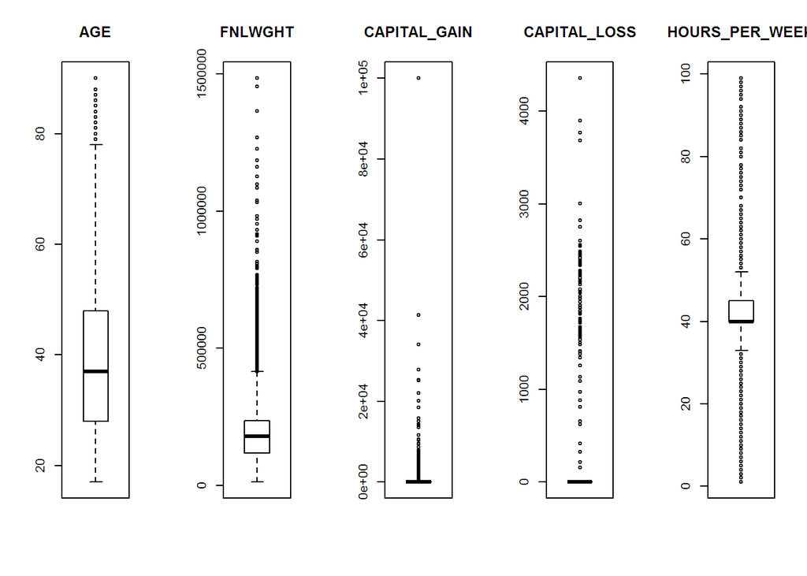

```r
par(mfrow=c(1,5))
for (i in num_list){boxplot(ORdata[,i], main=names(ORdata[i]))}
```

As seen in the plots, capital_gain and capital_loss have near zero variance.

Now let’s have a closer look into numeric variables.

- AGE

AGE variable seems to have significant effect on the TARGET.

```r
summary(ORdata$AGE)
```

```
##    Min. 1st Qu.  Median    Mean 3rd Qu.    Max.
##   17.00   28.00   37.00   38.58   48.00   90.00
```

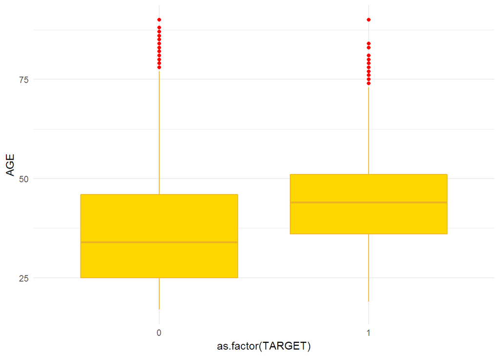

```r
ggplot(ORdata,aes(x=as.factor(TARGET),y=AGE), col=TARGET)+geom_boxplot(outlier.color = "red", fill="gold1", colour="goldenrod2")+theme_minimal()
```

- EDUCATION

EDUCATION seems to be a good classifier.

```r
summary(ORdata$EDUCATION_NUM)
```

```
##     1     2     3     4     5     6     7     8     9    10    11    12
##    51   168   333   646   514   933  1175   433 10501  7291  1382  1067
##    13    14    15    16
##  5355  1723   576   413
```

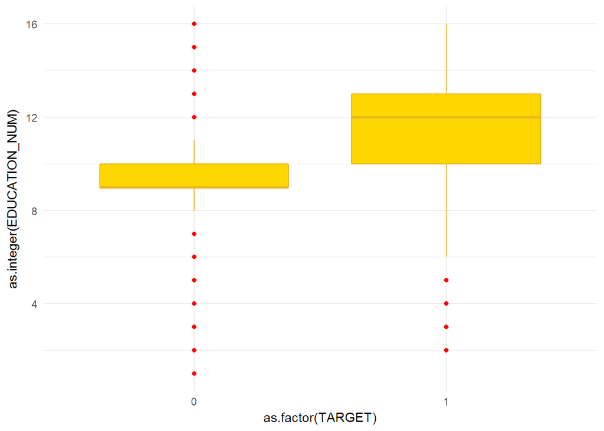

```r
ggplot(ORdata,aes(x=as.factor(TARGET),y=as.integer(EDUCATION_NUM)), col=TARGET)+geom_boxplot(outlier.color = "red", fill="gold1", colour="goldenrod2")+theme_minimal()
```

- CAPITAL_GAIN and CAPITAL_LOSS

Here is the data summary of 2 variables for TARGET=0.

```r
summary (ORdata[ORdata$TARGET == "0", c("CAPITAL_GAIN", "CAPITAL_LOSS")])
```

```
##   CAPITAL_GAIN      CAPITAL_LOSS
##  Min.   :    0.0   Min.   :   0.00
##  1st Qu.:    0.0   1st Qu.:   0.00
##  Median :    0.0   Median :   0.00
##  Mean   :  148.8   Mean   :  53.14
##  3rd Qu.:    0.0   3rd Qu.:   0.00
##  Max.   :41310.0   Max.   :4356.00
```

And this is the data summary of 2 variables for TARGET=1.

```r
summary (ORdata[ORdata$TARGET == "1", c("CAPITAL_GAIN", "CAPITAL_LOSS")])
```

```
##   CAPITAL_GAIN    CAPITAL_LOSS
##  Min.   :    0   Min.   :   0
##  1st Qu.:    0   1st Qu.:   0
##  Median :    0   Median :   0
##  Mean   : 4006   Mean   : 195
##  3rd Qu.:    0   3rd Qu.:   0
##  Max.   :99999   Max.   :3683
```

As seen in the summaries there are some difference between the means and the max values, so these variables can be used in the model.

- HOURS_PER_WEEK

This is also seemed to be a good classifier.

```r
summary(ORdata$HOURS_PER_WEEK)
```

```
##    Min. 1st Qu.  Median    Mean 3rd Qu.    Max.
##    1.00   40.00   40.00   40.44   45.00   99.00
```

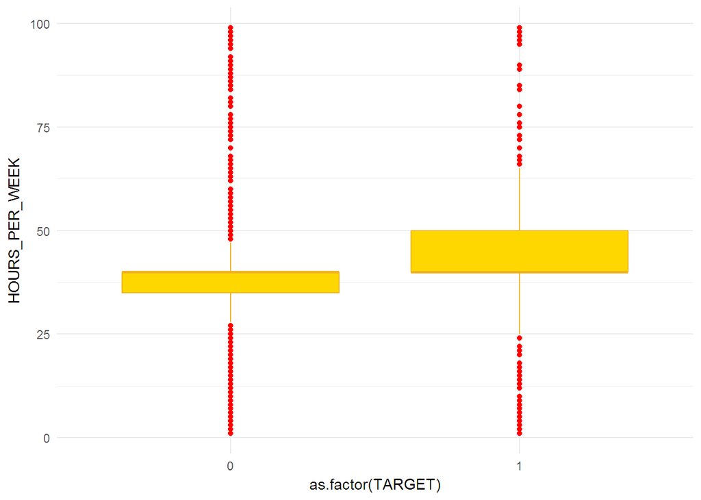

```r
ggplot(ORdata,aes(x=as.factor(TARGET),y=HOURS_PER_WEEK), col=TARGET)+geom_boxplot(outlier.color = "red", fill="gold1", colour="goldenrod2")+theme_minimal()
```

The following code will produce a couple of barplots showing relations of TARGET variable with categorical variables. When we look into plots categorical variables seem to have different levels of relations with TARGET variable. I will use all of the variables in the model since the dimension of the data is not too bad.

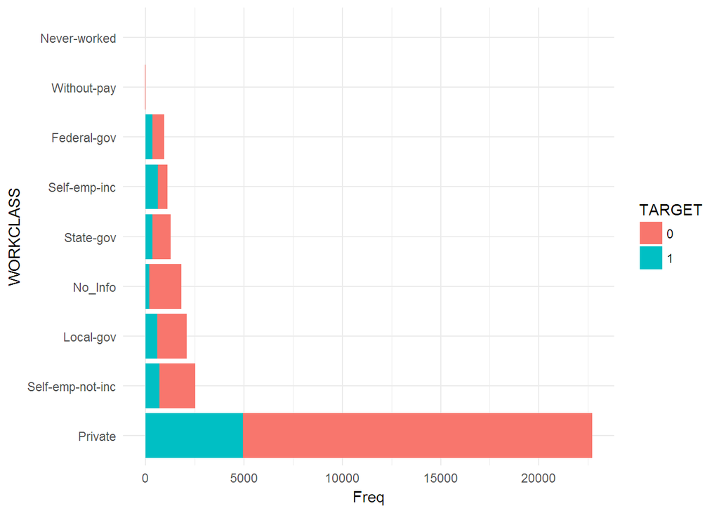

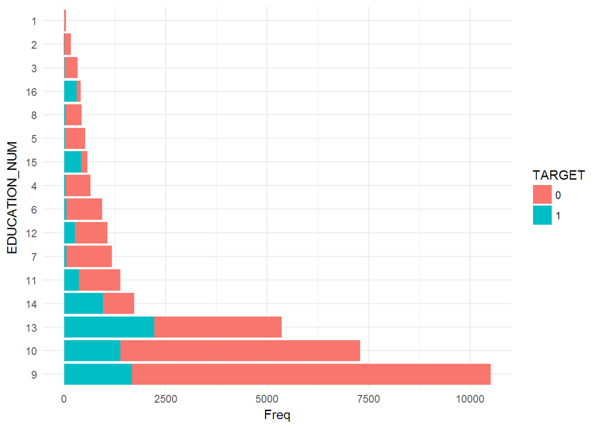

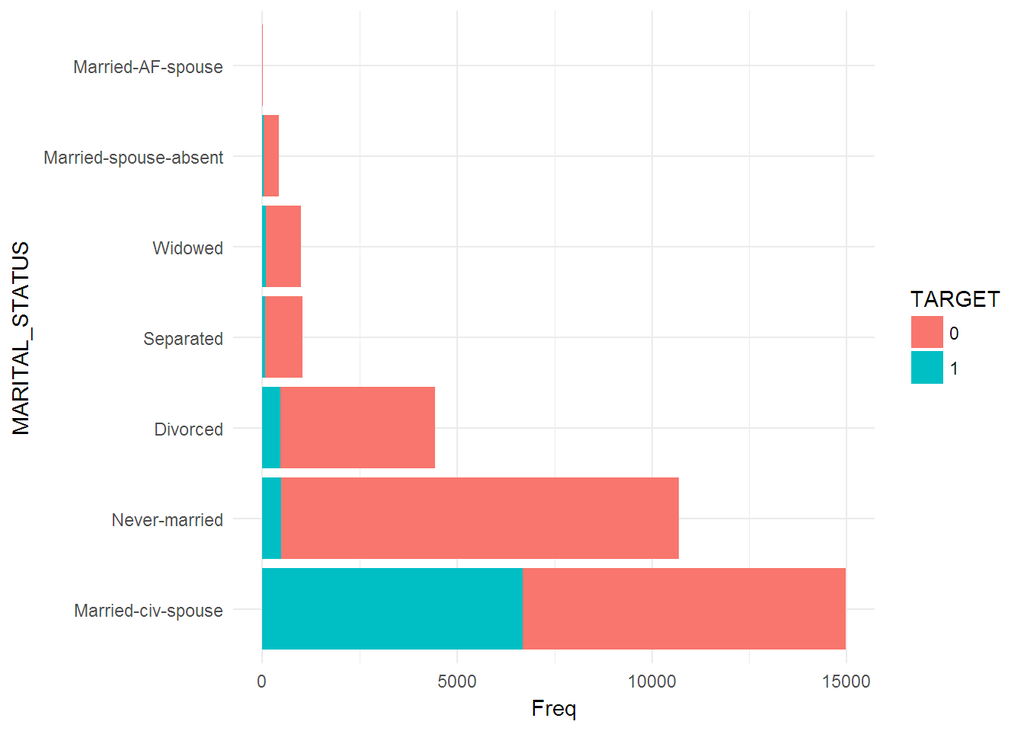

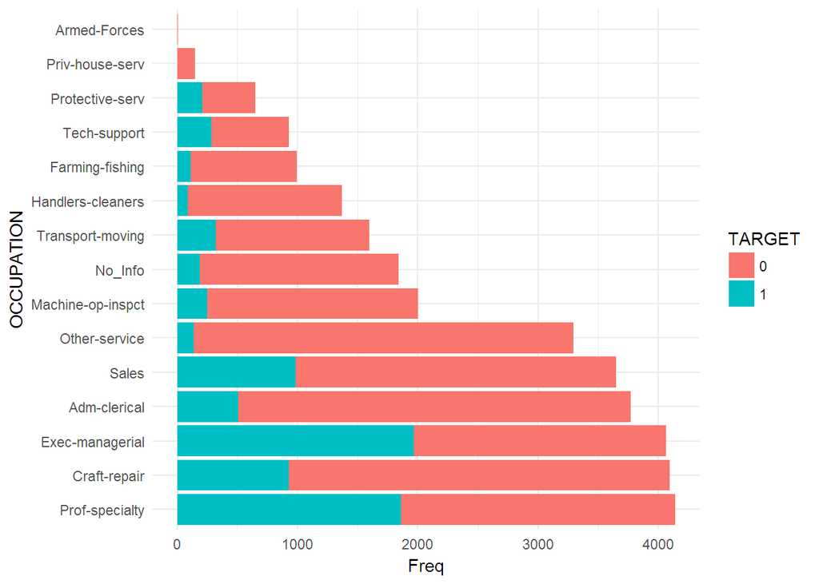

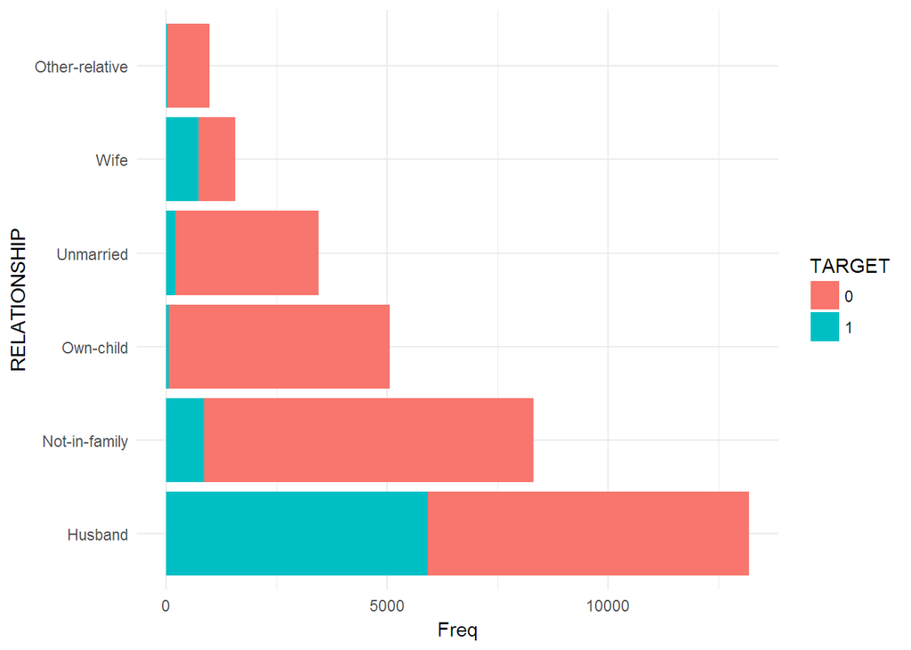

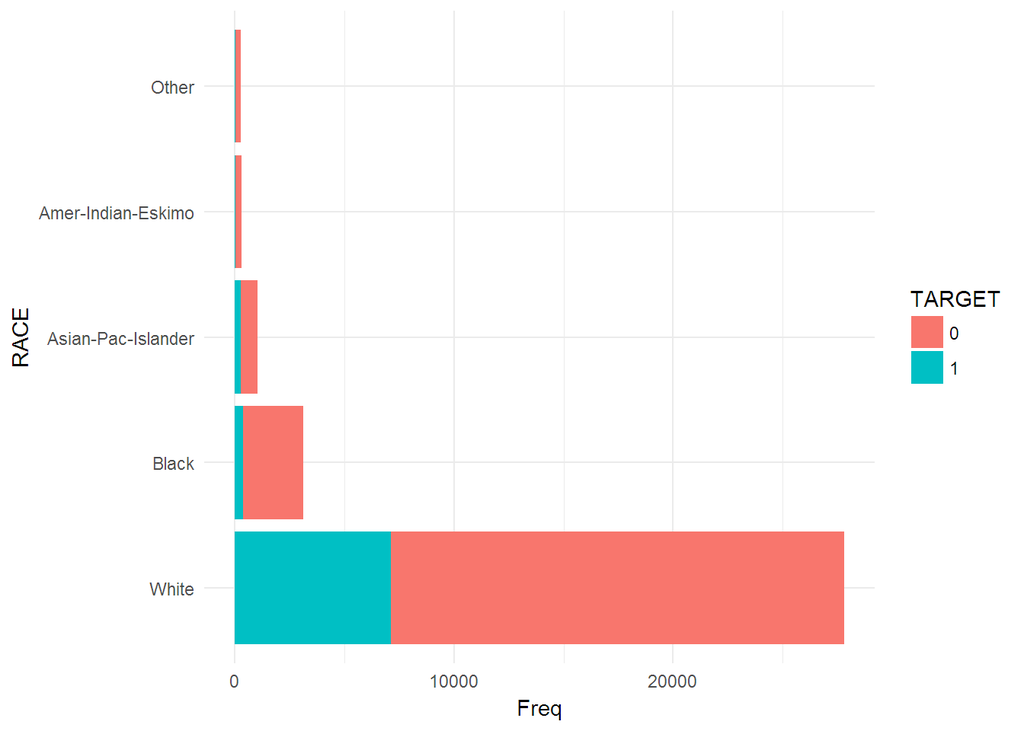

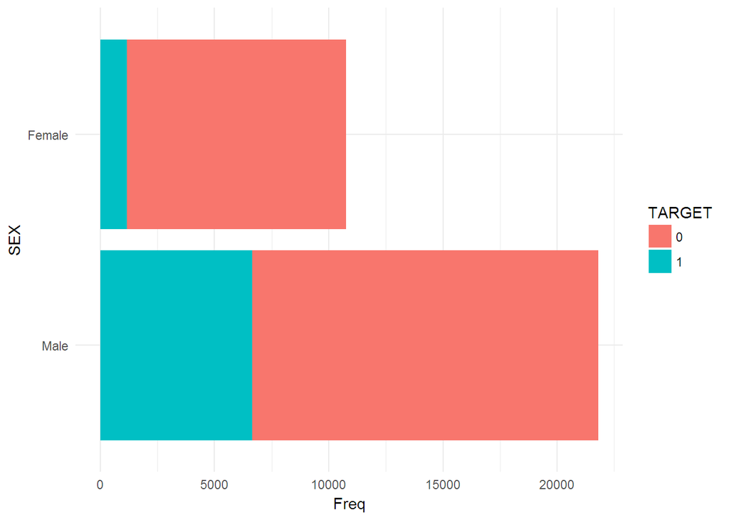

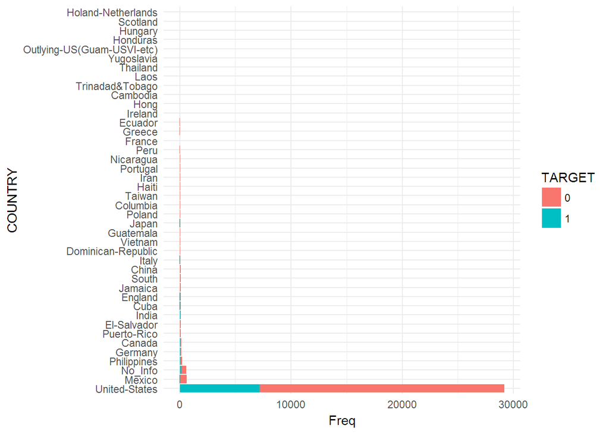

```r
p = list()
for (i in cat_list){
  counts <- data.frame(table(ORdata[,c(i,14)]))
  names(counts)[1] <- paste("Var")
  p[[i]] <- ggplot(counts, aes(x=reorder(Var, -Freq), y=Freq, fill=TARGET)) + geom_bar(stat="identity") + theme_minimal() +  coord_flip() + labs(x=names(ORdata[i]))
}
print(p)
```

## 2.4 Correlations

There is no significant correlation between continuous variables so we can use all in the model.

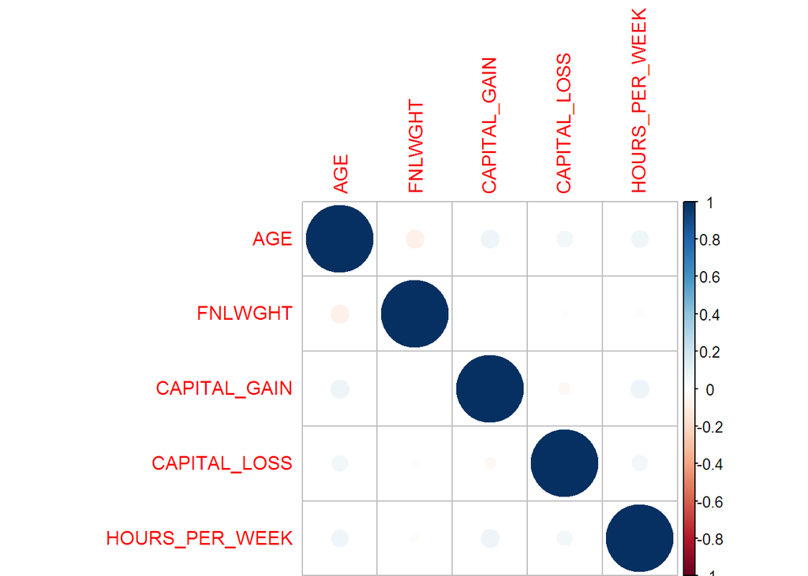

```r
correlations <- cor(ORdata[,num_list])
corrplot(correlations,method="circle")
```

## 2.5 Decision to Continue with Complete Cases or All Cases

Following steps have been performed for both data sets and since the algorithms perform slightly better with complete cases(without No_Info), i decided to continue with complete cases and represented the steps here.

With complete cases there isn’t a significant change in overall Accuracy and Sensitivity but xaccuracy for negative predictions(TARGET=1) is slightly better.

# 3. THE MODEL

## 3.1 Create Training, Validation and Test Sets

Following codes produce training, validation and test sets from the main data set. The percentages are 60, 20 and 20.

```r
df <- ORdataComplete

fractionTraining   <- 0.60
fractionValidation <- 0.20
fractionTest       <- 0.20

set.seed(1234)
sampleSizeTraining   <- floor(fractionTraining   * nrow(df))
sampleSizeValidation <- floor(fractionValidation * nrow(df))
sampleSizeTest       <- floor(fractionTest       * nrow(df))

set.seed(1234)
indicesTraining    <- sort(sample(seq_len(nrow(df)), size=sampleSizeTraining))
indicesNotTraining <- setdiff(seq_len(nrow(df)), indicesTraining)
indicesValidation  <- sort(sample(indicesNotTraining, size=sampleSizeValidation))
indicesTest        <- setdiff(indicesNotTraining, indicesValidation)

dfTraining   <- df[indicesTraining, ]
dfValidation <- df[indicesValidation, ]
dfTest       <- df[indicesTest, ]
```

## 3.2 Build Models

For this project i will perform gradient-boosting, C5.0 boosting, Naive Bayes, SVM algoritms to solve the classfication problem.

In order to shorten the model built times i use parallel processing library and run 4 algorihtms as follows.

```r
library(caret)
library('doParallel')
library(C50)
library(e1071)
cl <- makeCluster(4) #number of cores
registerDoParallel(cl)
set.seed(7)
boostFit = train(TARGET~., method = "gbm", data = dfTraining, verbose = FALSE)
set.seed(7)
c50Fit <- C5.0(TARGET~.,data=dfTraining)
set.seed(7)
NaiveFit <- naiveBayes(TARGET ~ ., data = dfTraining)
set.seed(7)
SVMFit <-svm(TARGET~., data = dfTraining)
stopCluster(cl)
```

Now we have 4 models on hand.

# 3.2.1 Model Validation

Following codes shows each model’s performance on validation set.

```r
# Boosting
table(predict(boostFit,dfValidation),dfValidation$TARGET)
```

```
##
##        0    1
##   0 4308  546
##   1  281  897
```

```r
confusionMatrix (dfValidation$TARGET, predict (boostFit, dfValidation))
```

```
## Confusion Matrix and Statistics
##
##           Reference
## Prediction    0    1
##          0 4308  281
##          1  546  897
##
##                Accuracy : 0.8629
##                  95% CI : (0.854, 0.8715)
##     No Information Rate : 0.8047
##     P-Value [Acc > NIR] : < 2.2e-16
##
##                   Kappa : 0.598
##  Mcnemar's Test P-Value : < 2.2e-16
##
##             Sensitivity : 0.8875
##             Specificity : 0.7615
##          Pos Pred Value : 0.9388
##          Neg Pred Value : 0.6216
##              Prevalence : 0.8047
##          Detection Rate : 0.7142
##    Detection Prevalence : 0.7608
##       Balanced Accuracy : 0.8245
##
##        'Positive' Class : 0
##
```

```r
# C5.0
table(predict(c50Fit,dfValidation),dfValidation$TARGET)
```

```
##
##        0    1
##   0 4223  484
##   1  366  959
```

```r
confusionMatrix (dfValidation$TARGET, predict (c50Fit, dfValidation))
```

```
## Confusion Matrix and Statistics
##
##           Reference
## Prediction    0    1
##          0 4223  366
##          1  484  959
##
##                Accuracy : 0.8591
##                  95% CI : (0.85, 0.8678)
##     No Information Rate : 0.7803
##     P-Value [Acc > NIR] : < 2.2e-16
##
##                   Kappa : 0.6017
##  Mcnemar's Test P-Value : 5.993e-05
##
##             Sensitivity : 0.8972
##             Specificity : 0.7238
##          Pos Pred Value : 0.9202
##          Neg Pred Value : 0.6646
##              Prevalence : 0.7803
##          Detection Rate : 0.7001
##    Detection Prevalence : 0.7608
##       Balanced Accuracy : 0.8105
##
##        'Positive' Class : 0
##
```

```r
# NaiveBayes
table(predict(NaiveFit,dfValidation),dfValidation$TARGET)
```

```
##
##        0    1
##   0 4319  812
##   1  270  631
```

```r
confusionMatrix (dfValidation$TARGET, predict (NaiveFit, dfValidation))
```

```
## Confusion Matrix and Statistics
##
##           Reference
## Prediction    0    1
##          0 4319  270
##          1  812  631
##
##                Accuracy : 0.8206
##                  95% CI : (0.8107, 0.8302)
##     No Information Rate : 0.8506
##     P-Value [Acc > NIR] : 1
##
##                   Kappa : 0.4344
##  Mcnemar's Test P-Value : <2e-16
##
##             Sensitivity : 0.8417
##             Specificity : 0.7003
##          Pos Pred Value : 0.9412
##          Neg Pred Value : 0.4373
##              Prevalence : 0.8506
##          Detection Rate : 0.7160
##    Detection Prevalence : 0.7608
##       Balanced Accuracy : 0.7710
##
##        'Positive' Class : 0
##
```

```r
# SVM
table(predict(SVMFit,dfValidation),dfValidation$TARGET)
```

```
##
##        0    1
##   0 4287  581
##   1  302  862
```

```r
confusionMatrix (dfValidation$TARGET, predict (SVMFit, dfValidation))
```

```
## Confusion Matrix and Statistics
##
##           Reference
## Prediction    0    1
##          0 4287  302
##          1  581  862
##
##                Accuracy : 0.8536
##                  95% CI : (0.8444, 0.8624)
##     No Information Rate : 0.807
##     P-Value [Acc > NIR] : < 2.2e-16
##
##                   Kappa : 0.5693
##  Mcnemar's Test P-Value : < 2.2e-16
##
##             Sensitivity : 0.8806
##             Specificity : 0.7405
##          Pos Pred Value : 0.9342
##          Neg Pred Value : 0.5974
##              Prevalence : 0.8070
##          Detection Rate : 0.7107
##    Detection Prevalence : 0.7608
##       Balanced Accuracy : 0.8106
##
##        'Positive' Class : 0
##
```

I tried different options but they did not make significant changes, so i decided to go with defaults.

But before deciding i want to try model ensemble which sometimes produces better results.

# 3.2.2 Model Ensemble

The following codes performs the ensemble of the models and make the prediction using this new model. But there is not significant change in the performance. Overall accuracy is sligthtly better than the standalone models.

```r
cl <- makeCluster(4) #number of cores
registerDoParallel(cl)

predBoostFit <- predict(boostFit,dfValidation)
predC50Fit <- predict(c50Fit,dfValidation)
predNaiveFit <- predict(NaiveFit,dfValidation)
predSVMFit <- predict(SVMFit,dfValidation)

predDF <- data.frame(predBoostFit,predSVMFit,predC50Fit,predNaiveFit,TARGET=dfValidation$TARGET)
combModFit <- train(TARGET~.,method="rf",data=predDF)
predModEns <- predict(combModFit,dfValidation)
confusionMatrix (dfValidation$TARGET, predict (combModFit, dfValidation))
```

```
## Confusion Matrix and Statistics
##
##           Reference
## Prediction    0    1
##          0 4344  245
##          1  563  880
##
##                Accuracy : 0.866
##                  95% CI : (0.8572, 0.8745)
##     No Information Rate : 0.8135
##     P-Value [Acc > NIR] : < 2.2e-16
##
##                   Kappa : 0.6019
##  Mcnemar's Test P-Value : < 2.2e-16
##
##             Sensitivity : 0.8853
##             Specificity : 0.7822
##          Pos Pred Value : 0.9466
##          Neg Pred Value : 0.6098
##              Prevalence : 0.8135
##          Detection Rate : 0.7202
##    Detection Prevalence : 0.7608
##       Balanced Accuracy : 0.8337
##
##        'Positive' Class : 0
##
```

```r
table(predModEns,dfValidation$TARGET)
```

```
##
## predModEns    0    1
##          0 4344  563
##          1  245  880
```

```r
stopCluster(cl)
```

## 3.3 Build Models with CV

I want to see the results when i apply cross-validation with 10 folds and 3 repeats, a common standard configuration for comparing models. Although this data set has enough observations, sometimes this method produces better results. Another reasoun i would like to do so is in order to verify boosting algorithms perform better with this data set. It is always good idea to see the performance of algorithms with different resamples of data.

```r
library(mlbench)
library(caret)
cl <- makeCluster(4) #number of cores
registerDoParallel(cl)
# prepare training scheme
trainControl <- trainControl(method="repeatedcv", number=10, repeats=3)
# CART
set.seed(7)
mod.cart <- train(TARGET~., data=dfTraining, method="rpart", trControl=trainControl)
# GBM
set.seed(7)
mod.gbm <- train(TARGET~., data=dfTraining, method="gbm", trControl=trainControl)
# SVM
set.seed(7)
mod.svm <- train(TARGET~., data=dfTraining, method="svmRadial", trControl=trainControl)
# KNN
set.seed(7)
mod.knn <- train(TARGET~., data=dfTraining, method="knn", trControl=trainControl)
# C50
set.seed(7)
mod.c50 <- train(TARGET~., data=dfTraining, method="C5.0", trControl=trainControl)
# collect resamples
results <- resamples(list(CART=mod.cart, GBM=mod.gbm, SVM=mod.svm, KNN=mod.knn, C50=mod.c50))
stopCluster(cl)
```

Let’s see the summary of results with different algorithms.

```r
# summarize differences between models
summary(results)
```

```
##
## Call:
## summary.resamples(object = results)
##
## Models: CART, GBM, SVM, KNN, C50
## Number of resamples: 30
##
## Accuracy
##        Min. 1st Qu. Median   Mean 3rd Qu.   Max. NA's
## CART 0.7933  0.7995 0.8019 0.8034  0.8069 0.8237    0
## GBM  0.8464  0.8553 0.8585 0.8591  0.8632 0.8719    0
## SVM  0.7739  0.7835 0.7871 0.7867  0.7902 0.7955    0
## KNN  0.7635  0.7710 0.7751 0.7753  0.7799 0.7862    0
## C50  0.8524  0.8631 0.8655 0.8669  0.8715 0.8789    0
##
## Kappa
##        Min. 1st Qu. Median   Mean 3rd Qu.   Max. NA's
## CART 0.2629  0.3054 0.3462 0.3412  0.3687 0.4462    0
## GBM  0.5604  0.5867 0.5954 0.5972  0.6096 0.6414    0
## SVM  0.1688  0.2170 0.2300 0.2299  0.2480 0.2682    0
## KNN  0.2144  0.2350 0.2510 0.2521  0.2681 0.2943    0
## C50  0.5848  0.6182 0.6242 0.6282  0.6405 0.6606    0
```

Graphical representation of plots is as shown below. Boosting algorithms performs definitly better with this data set.

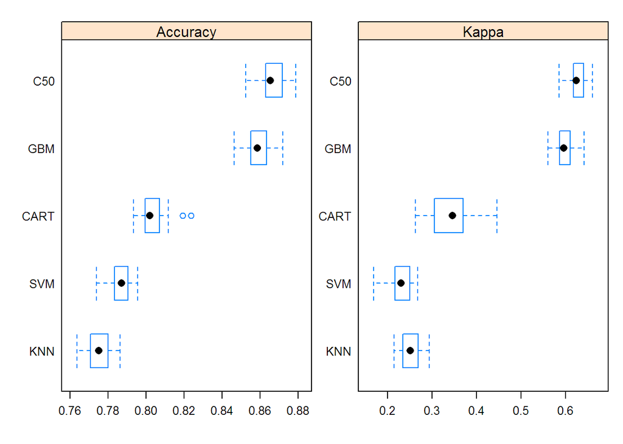

```r
# box and whisker plots to compare models
scales <- list(x=list(relation="free"), y=list(relation="free"))
bwplot(results, scales=scales)
```

Here are the statistical significancy tests verifying GBM and C5.0 performs better. So we can elect C5.0 as the preffered method for this project.

```r
# difference in model predictions
diffs <- diff(results)
# summarize p-values for pairwise comparisons
summary(diffs)
```

```
##
## Call:
## summary.diff.resamples(object = diffs)
##
## p-value adjustment: bonferroni
## Upper diagonal: estimates of the difference
## Lower diagonal: p-value for H0: difference = 0
##
## Accuracy
##      CART      GBM       SVM       KNN       C50
## CART           -0.055718  0.016688  0.028053 -0.063546
## GBM  < 2.2e-16            0.072406  0.083771 -0.007828
## SVM  1.176e-13 < 2.2e-16            0.011365 -0.080234
## KNN  4.854e-16 < 2.2e-16 1.614e-12           -0.091599
## C50  < 2.2e-16 4.775e-08 < 2.2e-16 < 2.2e-16
##
## Kappa
##      CART      GBM       SVM       KNN       C50
## CART           -0.25603   0.11136   0.08914  -0.28698
## GBM  < 2.2e-16            0.36739   0.34517  -0.03095
## SVM  1.020e-12 < 2.2e-16           -0.02222  -0.39835
## KNN  8.222e-10 < 2.2e-16 4.844e-07           -0.37613
## C50  < 2.2e-16 2.410e-11 < 2.2e-16 < 2.2e-16
```

## 4. Model Election and Running the Elected Model on Test Set

Boosting models(C5.0 and GBM) has better overall accuracy and better specificity.

C5.0 scores are very close to gradient-boosting method but it has better negative prediction value.

I think at this time it should be a business decision which method to use. Sometimes overall accuracy is important and we select GBM for this case. But sometimes predicting the negative class is important, and we select C5.0 method for increasing the accuracy in prediction of negative class. As in this case predicting if a person has an income more than 50K is the main concern i would probably select C5.0.

As seen in the following part, our model works well on the test set. Model does not have overfitting issue which means generalization is achieved well.

```r
# C5.0
table(predict(c50Fit,dfTest),dfTest$TARGET)
```

```
##
##        0    1
##   0 4203  498
##   1  347  985
```

```r
confusionMatrix (dfTest$TARGET, predict (c50Fit, dfTest))
```

```
## Confusion Matrix and Statistics
##
##           Reference
## Prediction    0    1
##          0 4203  347
##          1  498  985
##
##                Accuracy : 0.8599
##                  95% CI : (0.8509, 0.8686)
##     No Information Rate : 0.7792
##     P-Value [Acc > NIR] : < 2.2e-16
##
##                   Kappa : 0.6088
##  Mcnemar's Test P-Value : 2.467e-07
##
##             Sensitivity : 0.8941
##             Specificity : 0.7395
##          Pos Pred Value : 0.9237
##          Neg Pred Value : 0.6642
##              Prevalence : 0.7792
##          Detection Rate : 0.6967
##    Detection Prevalence : 0.7542
##       Balanced Accuracy : 0.8168
##
##        'Positive' Class : 0
##
```

And here are the results with C5.0 model built with cross-validation.

```r
# C5.0
table(predict(mod.c50,dfTest),dfTest$TARGET)
```

```
##
##        0    1
##   0 4260  510
##   1  290  973
```

```r
confusionMatrix (dfTest$TARGET, predict (mod.c50, dfTest))
```

```
## Confusion Matrix and Statistics
##
##           Reference
## Prediction    0    1
##          0 4260  290
##          1  510  973
##
##                Accuracy : 0.8674
##                  95% CI : (0.8586, 0.8759)
##     No Information Rate : 0.7907
##     P-Value [Acc > NIR] : < 2.2e-16
##
##                   Kappa : 0.6235
##  Mcnemar's Test P-Value : 9.724e-15
##
##             Sensitivity : 0.8931
##             Specificity : 0.7704
##          Pos Pred Value : 0.9363
##          Neg Pred Value : 0.6561
##              Prevalence : 0.7907
##          Detection Rate : 0.7061
##    Detection Prevalence : 0.7542
##       Balanced Accuracy : 0.8317
##
##        'Positive' Class : 0
##
```

## 5. Summary

We know that 25% of data is in class TARGET=1 roughly and 75% is in TARGET=0. Algorithms process data assuming 0 is positive class and thus we expect a sensitivity score higher than 75% percent and a specificity score higher than 25%.

We have satisfactionary results at the end. Model provided 86% overall accuracy, 89% sensitivity, 75% specificity and 66% negative prediction value.